# Trustworthy AI in Julia meets Supercomputing

JuliaCon 2024

Patrick Altmeyer

Friday, July 12, 2024

## Trustworthy AI in JuliA

```
%%{
  init: {
    'theme': 'base',
    'themeVariables': {
      'primaryColor': '#BB2528',
      'primaryTextColor': '#fff',
      'primaryBorderColor': '#7C0000',
      'lineColor': '#F8B229',
      'secondaryColor': '#006100',
      'tertiaryColor': '#e9edfb',
      'fontFamily': "avenir"
    }
  }
}%%

flowchart TB

    classDef taija fill:#389836,stroke:#333,color:#fff;
    classDef core fill:#CB3C33,stroke:#333,color:#fff;
    classDef base fill:#9558B2,stroke:#333,color:#fff;

    %% Base
    base["TaijaBase.jl"]

    %% Meta
    interop["TaijaInteroperability.jl"]
    data["TaijaData.jl"]
    parallel["TaijaParallel.jl"]
    plotting["TaijaPlotting.jl"]

    %% Core
    ce["CounterfactualExplanations.jl"]
    cp["ConformalPrediction.jl"]
    lr["LaplaceRedux.jl"]
    jem["JointEnergyModels.jl"]

    %% External
    mlj["MLJ.jl"]
    flux["Flux.jl"]

    class base base;
    class interop,data,parallel,plotting taija;
    class ce,cp,lr,jem core;

    %% Graph
    base --> ce & cp & lr & jem

    subgraph "Core Packages"
        ce & cp & lr & jem
    end

    subgraph "Meta Packages"
        data & plotting & parallel & interop
    end

    subgraph "External Packages"
        mlj & flux
    end
```

Figure 1: Overview of the Taija ecosystem. Early-stage packages ommitted.

# TaijaParallel.jl

[figure not shown]

This package adds custom support for parallelization for certain [Taija](https://github.com/JuliaTrustworthyAI) packages.

- Intuitive user interface.
- Support for multi-threading and multi-processing.
- Easy to extend to new parallelization backends and functions.

## Why Supercomputing?

Efforts towards trustworthy AI tend to increase the computational burden involved in training or inference:

- Explainable AI: we are often required to generate many *local* explanations for many individuals.
- Conformal Prediction: many techniques involve cross-validation or bootstrapping.
- (Quasi) Bayesian DL like deep ensembles.

> Good news: all of these tasks can be parallelized!

# Motivating Example

> Generate ALL the Counterfactual Explanations!
- The package was developed to power [research](https://arxiv.org/abs/2312.10648) presented at AAAI 2024 (Altmeyer et al. 2024).
- The project involved large benchmarks of counterfactual explanations that had to be run on a supercomputer.

## Benchmarking Explanations

**Goal**: Generate faithful counterfactual explanations that reflect model quality.

- Final benchmark: total of **~10 million** counterfactuals across 8 datasets and different DL models.
- Parallelized across **50 to 300 CPUs** on [DelftBlue](https://www.tudelft.nl/dhpc/system) using combination of multi-threading and -processing.

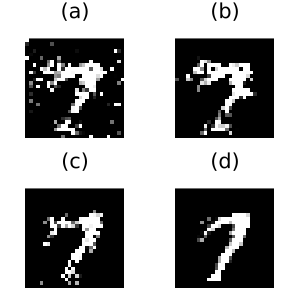

Counterfactual explanations for different models. Source: Altmeyer et al. (2024)

## Source Code

- [ECCCo.jl](https://github.com/pat-alt/ECCCo.jl/tree/main) is a small package build for Altmeyer et al. (2024) that leverages and extends CounterfactualExplanations.jl, ConformalPrediction.jl, and JointEnergyModels.jl.
- Parallelization is achieved through [TaijaParallel.jl](https://github.com/JuliaTrustworthyAI/TaijaParallel.jl/tree/main).
- Functionality now being absorbed by CounterfactualExplanations.jl.

> Code is open-sourced and available on [GitHub](https://github.com/pat-alt/ECCCo.jl/tree/main).

[figure not shown]

# The Package

## User Interface

> We aim to minimize the burden on users.
- Users will mostly interact with custom macro `@with_parallelizer`.
- In Figure 2, `mpi` is an instance of type `MPIParallelizer`.

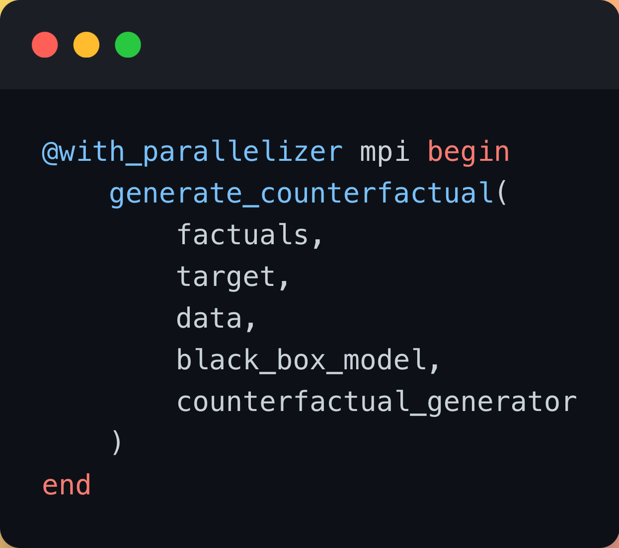

Figure 2: Generating counterfactuals in parallel using MPI. See [docs](https://juliatrustworthyai.github.io/CounterfactualExplanations.jl/stable/tutorials/parallelization/) for details.

## High-level Architecture

- TaijaBase.jl ships basic parallelization [functions and symbols](https://github.com/JuliaTrustworthyAI/TaijaBase.jl/blob/main/src/parallelization/base.jl) to make them available to all Taija packages.
  - `CounterfactualExplanations.benchmark`, for example, accepts a `parallelizer` argument of type `Union{Nothing,AbstractParallelizer}`.
- TaijaParallel.jl adds out-of-the-box support for parallelization through multi-threading.
- Multi-processing through MPI.jl handled through an extension.

## Backend

- The `@with_parallelizer` macro defined [here](https://github.com/JuliaTrustworthyAI/TaijaParallel.jl/blob/8534c12b67a9f1ecda0186d992843d249e6a0a28/src/TaijaParallel.jl#L27C7-L27C24) parses inputs and calls the `parallelize` function.
- `parallelize` is dispatched on the type of `parallelizer` and the function to be parallelized.
- Easy to add support for new parallelization backends and functions by overloading `parallelize`.
- Possible to combine different forms of parallelization, e.g., multi-threading and multi-processing (see [here](https://github.com/JuliaTrustworthyAI/TaijaParallel.jl/blob/8534c12b67a9f1ecda0186d992843d249e6a0a28/ext/MPIExt/generate_counterfactual.jl#L15) for an example).

## Caveats and Future Work

- The functions to be parallelized must be broadcastable: `generate_counterfactual`, for example, can be broadcasted over a batch of inputs.
- Currently, the package only supports CounterfactualExplanations.jl.
- Work on ConformalPrediction.jl is in progress, and hinges on the ability to parallelize cross-validation. Requires [changes](https://github.com/JuliaTrustworthyAI/ConformalPrediction.jl/pull/119) to ConformalPrediction.jl.

## ALL the Counterfactuals!

Trustworthy AI may be slow but …

> Julia go vroom vroom!

[figure not shown]

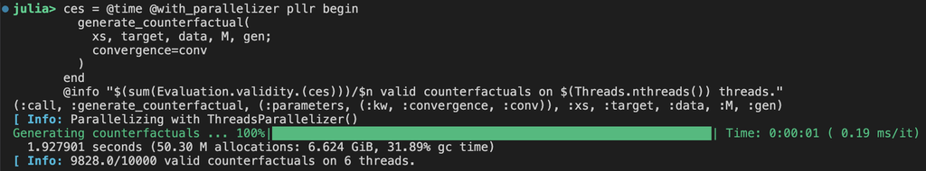

Generating 10,000 counterfactuals for MNIST in parallel in under 2s on a MacBook.

# Questions?

[figure not shown]

## References

Altmeyer, Patrick, Mojtaba Farmanbar, Arie van Deursen, and Cynthia CS Liem. 2024. “Faithful Model Explanations Through Energy-Constrained Conformal Counterfactuals.” *Proceedings of the AAAI Conference on Artificial Intelligence* 38: 10829–37.